# Análisis Comparativo de Indicadores: Argentina-Chile

Brechas migratorias (nativos - migrantes)

Natalia Debandi

2026-02-22

# Analisis de indicadores

Fuentes

- **EPH (Argentina)**: Encuesta Permanente de Hogares, 2016-2024
- **CASEN (Chile)**: Caracterización Socioeconómica Nacional, 2015-2024
- **ENE (Chile)**: Encuesta Nacional de Empleo, datos mensuales

**cargar datos**

NOTAS: **cHILE**

En el caso e Chile para cada año y grupo se prioriza ENE y si no existe se usa CASEN.

**ARGENTINA**

```
## Unificando fuentes de Chile (ENE > CASEN)...
```

```
##   Indicadores con ENE: I3_informalidad_asalariada, I1_tasa_actividad, I2_tasa_desempleo
```

**Calculo de brechas**

Se calcular para cada año_

Brecha 1= Nativos - migrantes (todos)

Brecha 2= Nativos - migrantes recientes (5 años o menos desde que llegaron al paìs)

```
## Calculando brechas por año individual...
```

```
## ✓ Brechas calculadas por año individual
```

```
##   Total de observaciones: 142
```

## Atencion!!!

–> Los indicadores calculados no tiene todos la misma dirección para su interpretación y el análisis de las brechas.

Por ejemplo: una mayor tasa de pobreza en personas migrantes indica MENOR INTEGRACIÓN O ACCESO A DERECHOS mientras que una tasa de asistencia a la universidad mayor en personas migrantes indica MAYOR INTEGRACIÓN O ACCESO A DERECHOS.

# Analisis de calidad de la muestra

En esta sección se incorpora un diagnóstico de calidad muestral para cada estimación (indicador × país × año × grupo migratorio), con el objetivo de evaluar la robustez de los resultados, especialmente en subpoblaciones pequeñas como migrantes recientes. Dado que los indicadores se calculan a partir de encuestas con factores de expansión (ponderadores), el tamaño muestral relevante para inferencia no es únicamente el número de casos observados, sino el tamaño muestral efectivo, que aproxima cuánta información “real” aporta la muestra una vez considerado el grado de desigualdad de los ponderadores.

n_con_peso: número de observaciones con ponderador válido (tamaño muestral disponible para el cálculo).

Con base en estas métricas se define un semáforo de calidad:

**OK:** n_con_peso ≥ 100 y n_eff_kish ≥ 50 (estimación suficientemente estable).

**CUIDADO:** n_con_peso ≥ 30 y n_eff_kish ≥ 30 (interpretar con cautela; útil para descriptivos, sensible a fluctuaciones).

**NO USAR:** casos restantes (estimación potencialmente inestable; no se recomienda para comparaciones o síntesis multivariadas).

```
## Resumen de calidad (conteo de estimaciones):
```

```
## # A tibble: 3 × 2
##   calidad_muestra     n
##   <fct>           <int>
## 1 OK                380
## 2 CUIDADO             6
## 3 NO USAR             4
```

```
##
## Casos que requieren atención (CUIDADO / NO USAR):
```

```
## # A tibble: 10 × 8
##    pais      fuente indicador        anio grupo_migratorio n_con_peso n_eff_kish
##    <chr>     <chr>  <chr>           <dbl> <chr>                 <dbl>      <dbl>
##  1 Argentina EPH    I3_informalida…  2016 migrantes_recie…         94       50.0
##  2 Argentina EPH    I8_asistencia_…  2016 migrantes_recie…         41       17.1
##  3 Argentina EPH    I8_asistencia_…  2017 migrantes_recie…         83       37.2
##  4 Argentina EPH    I8_asistencia_…  2020 migrantes_recie…         73       29.5
##  5 Argentina EPH    I8_asistencia_…  2021 migrantes_recie…         83       26.0
##  6 Argentina EPH    I8_asistencia_…  2022 migrantes_recie…         81       44.6
##  7 Argentina EPH    I8_asistencia_…  2023 migrantes_recie…         74       39.1
##  8 Argentina EPH    I8_asistencia_…  2024 migrantes_recie…         57       26.8
##  9 Argentina EPH    I9_asistencia_…  2020 migrantes_recie…        130       48.4
## 10 Argentina EPH    I9_asistencia_…  2021 migrantes_recie…        102       36.5
## # ℹ 1 more variable: calidad_muestra <fct>
```

# (I1) Tasa de actividad

## Datos completos

### Argentina

| pais | fuente | anio | indicador_clean | nativos | migrantes | migrantes_recientes | brecha_nat_mig | brecha_nat_rec |
| --- | --- | --- | --- | --- | --- | --- | --- | --- |
| Argentina | EPH | 2016 | Tasa Actividad | 45.49 | 52.78 | 58.63 | -7.29 | -13.14 |
| Argentina | EPH | 2017 | Tasa Actividad | 45.50 | 55.15 | 60.74 | -9.65 | -15.25 |
| Argentina | EPH | 2018 | Tasa Actividad | 46.12 | 55.67 | 59.36 | -9.55 | -13.24 |
| Argentina | EPH | 2019 | Tasa Actividad | 46.90 | 55.84 | 64.05 | -8.94 | -17.15 |
| Argentina | EPH | 2020 | Tasa Actividad | 42.88 | 51.85 | 56.40 | -8.97 | -13.52 |
| Argentina | EPH | 2021 | Tasa Actividad | 46.21 | 56.62 | 59.96 | -10.41 | -13.75 |
| Argentina | EPH | 2022 | Tasa Actividad | 46.98 | 57.98 | 60.57 | -11.00 | -13.59 |
| Argentina | EPH | 2023 | Tasa Actividad | 47.71 | 58.70 | 48.58 | -10.99 | -0.88 |
| Argentina | EPH | 2024 | Tasa Actividad | 55.93 | 61.50 | 58.80 | -5.57 | -2.87 |

### Chile

| pais | fuente | anio | indicador_clean | nativos | migrantes | migrantes_recientes | brecha_nat_mig | brecha_nat_rec |
| --- | --- | --- | --- | --- | --- | --- | --- | --- |
| Chile | ENE | 2017 | Tasa Actividad | 62.70 | 79.57 | NA | -16.87 | NA |
| Chile | ENE | 2018 | Tasa Actividad | 62.36 | 81.20 | NA | -18.85 | NA |
| Chile | ENE | 2019 | Tasa Actividad | 62.93 | 81.30 | NA | -18.37 | NA |
| Chile | ENE | 2020 | Tasa Actividad | 53.36 | 72.32 | NA | -18.96 | NA |
| Chile | ENE | 2021 | Tasa Actividad | 57.11 | 78.98 | NA | -21.86 | NA |
| Chile | ENE | 2022 | Tasa Actividad | 59.70 | 78.27 | NA | -18.57 | NA |
| Chile | ENE | 2023 | Tasa Actividad | 60.94 | 80.29 | NA | -19.35 | NA |
| Chile | ENE | 2024 | Tasa Actividad | 61.74 | 80.11 | NA | -18.38 | NA |

## Datos por perìodo

Tasa de actividad (I1) — Niveles y brecha por período

Brecha = Nativos - Migrantes (puntos porcentuales). Chile: ENE prioritaria; CASEN si corresponde al indicador.

| Período | Argentina Nativos | Argentina Migrantes | Argentina Brecha | Chile Nativos | Chile Migrantes | Chile Brecha |
| --- | --- | --- | --- | --- | --- | --- |
| 2015-2016 | 45.5 | 52.8 | −7.3 | NA | NA | NA |
| 2017-2019 | 46.2 | 55.5 | −9.4 | 62.7 | 80.7 | −18.0 |
| 2020-2022 | 45.4 | 55.5 | −10.1 | 56.7 | 76.5 | −19.8 |
| 2023-2024 | 51.8 | 60.1 | −8.3 | 61.3 | 80.2 | −18.9 |

## Serie temporal

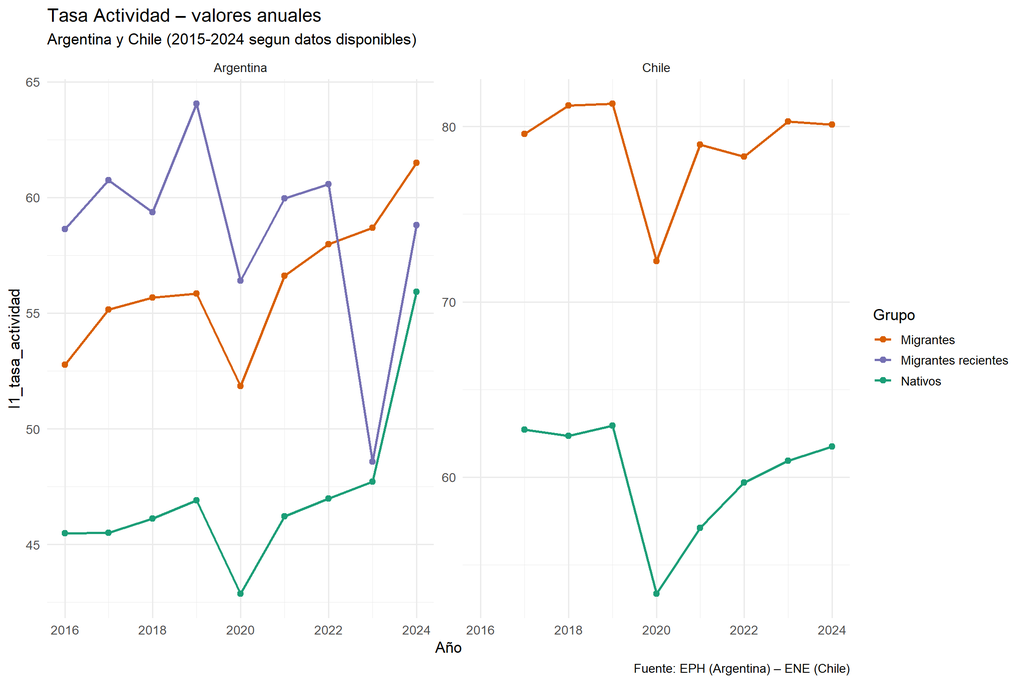

## Brechas nativos - migrantes

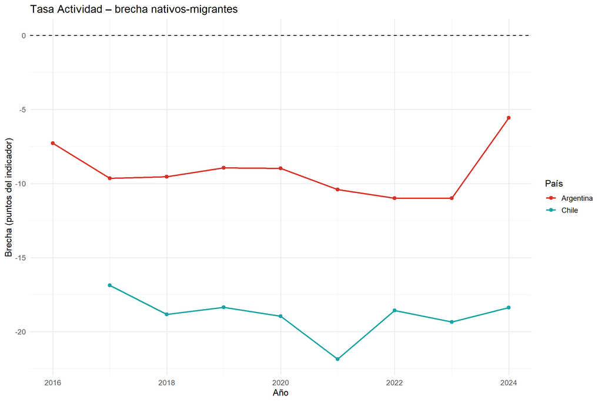

##Brechas - incorporación migración reciente

EN CHile la fuente ENE no contempla esta información.

Es más relevante el análisis para Argentina porque permite mayor comparibilidad con Chile donde la migración está más concentrada en migración reciente

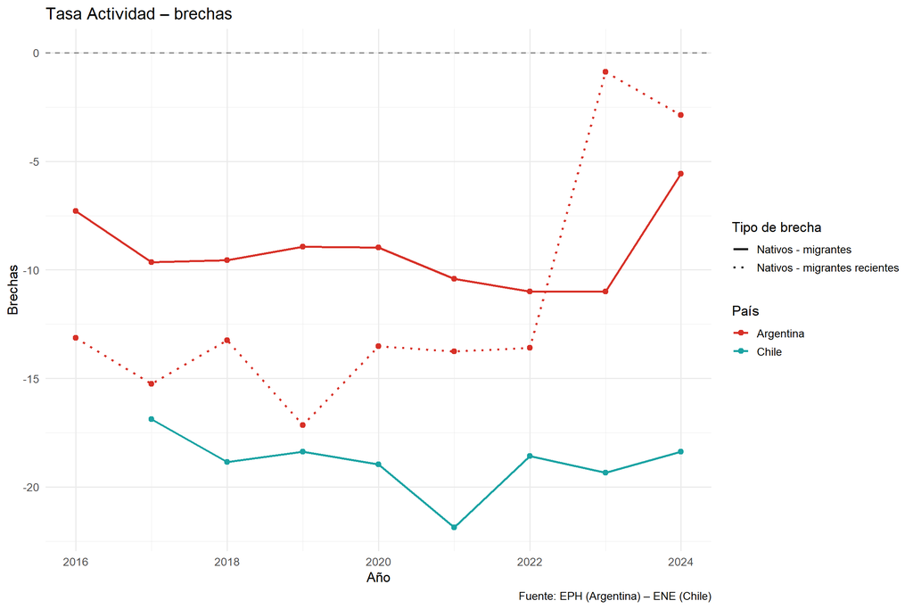

## Brechas estandarizadas

Bajo esta transformación, las brechas estandarizadas se interpretan como desviaciones respecto del promedio del indicador:

```
Z_(i,c,t)>0: integración relativa de la población migrante superior al promedio del indicador

Z_(i,c,t)<0: integración relativa inferior al promedio

Z_(i,c,t)=0: brecha equivalente al promedio del indicador
```

La magnitud de Z_(i,c,t)indica cuántos desvíos estándar se encuentra la brecha observada respecto de la media.

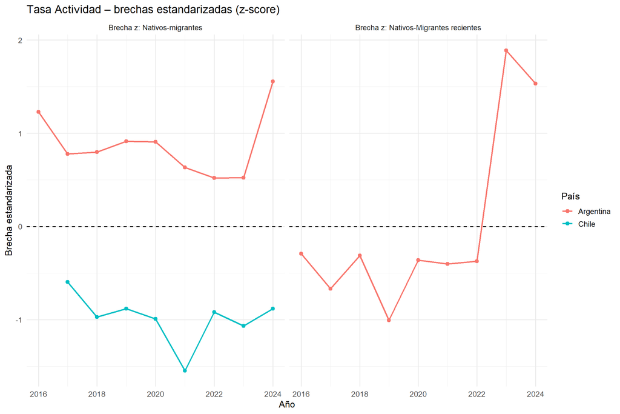

## Distribución de brechas

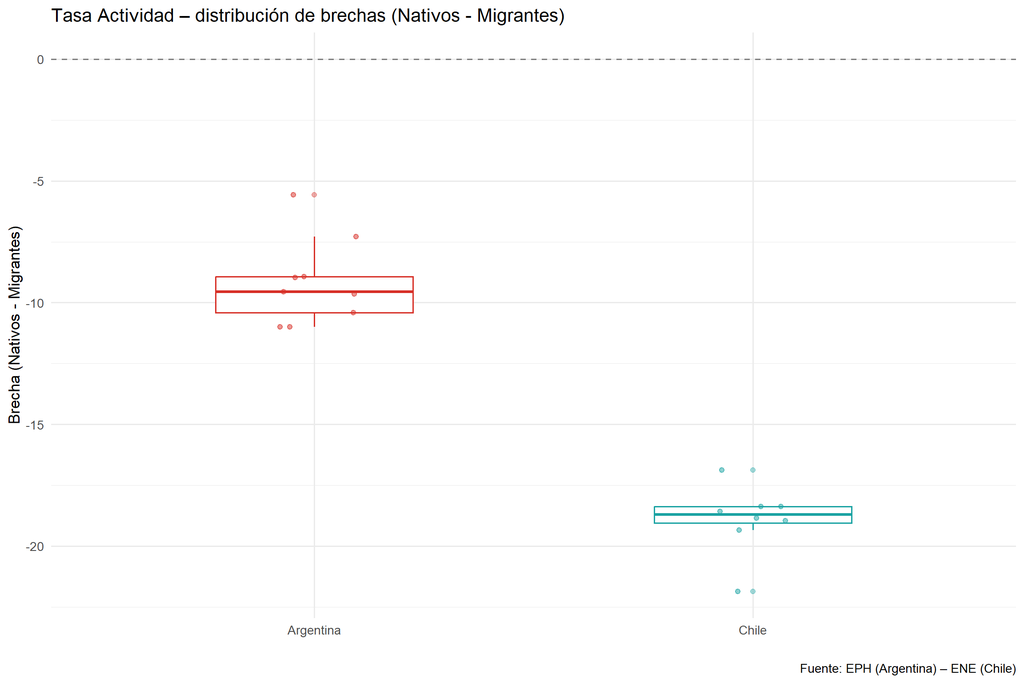

## Distribucion de brechas - grafico 2

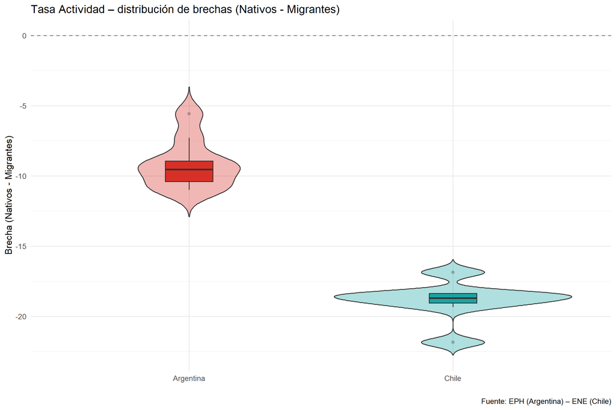

## distribucion de brechas migracion general y reciente en Argentina

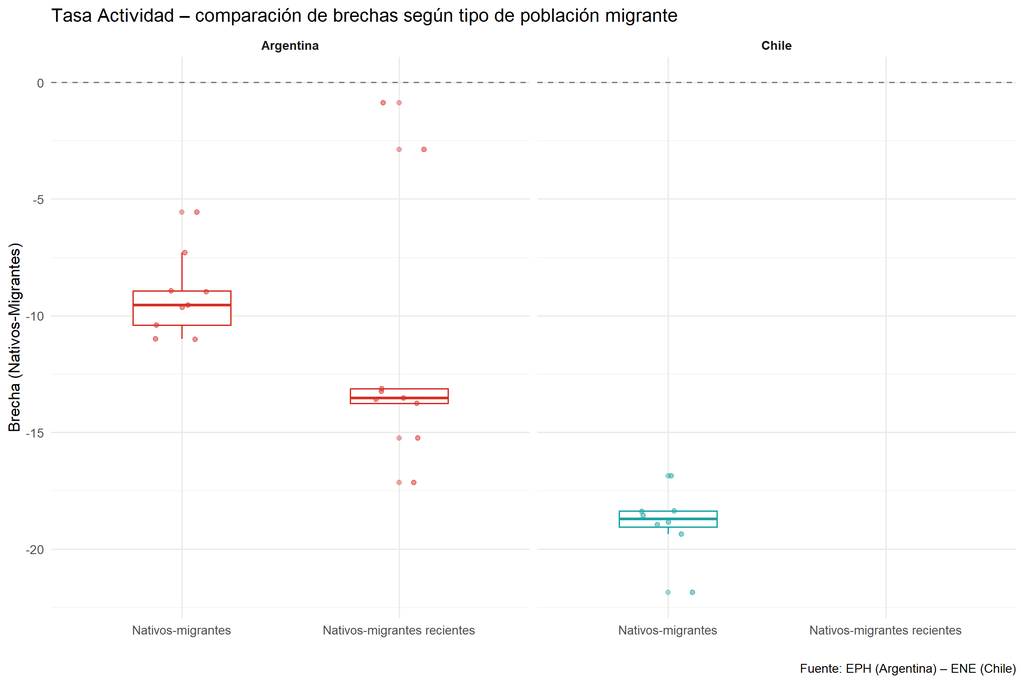

# (I2) Tasa de desempleo

## Datos completos

### Argentina

| pais | fuente | anio | indicador_clean | nativos | migrantes | migrantes_recientes | brecha_nat_mig | brecha_nat_rec |
| --- | --- | --- | --- | --- | --- | --- | --- | --- |
| Argentina | EPH | 2016 | Tasa Desempleo | 8.54 | 7.30 | 18.13 | 1.24 | -9.59 |
| Argentina | EPH | 2017 | Tasa Desempleo | 8.38 | 8.00 | 12.15 | 0.37 | -3.77 |
| Argentina | EPH | 2018 | Tasa Desempleo | 9.27 | 8.48 | 11.28 | 0.79 | -2.01 |
| Argentina | EPH | 2019 | Tasa Desempleo | 9.93 | 8.51 | 9.68 | 1.41 | 0.24 |
| Argentina | EPH | 2020 | Tasa Desempleo | 11.37 | 12.90 | 15.30 | -1.53 | -3.93 |
| Argentina | EPH | 2021 | Tasa Desempleo | 8.68 | 9.61 | 11.37 | -0.93 | -2.69 |
| Argentina | EPH | 2022 | Tasa Desempleo | 6.88 | 5.57 | 7.69 | 1.32 | -0.80 |
| Argentina | EPH | 2023 | Tasa Desempleo | 6.25 | 4.44 | 6.64 | 1.81 | -0.39 |
| Argentina | EPH | 2024 | Tasa Desempleo | 7.23 | 5.78 | 14.72 | 1.45 | -7.48 |

### Chile

| pais | fuente | anio | indicador_clean | nativos | migrantes | migrantes_recientes | brecha_nat_mig | brecha_nat_rec |
| --- | --- | --- | --- | --- | --- | --- | --- | --- |
| Chile | ENE | 2017 | Tasa Desempleo | 7.0 | 5.6 | NA | 1.4 | NA |
| Chile | ENE | 2018 | Tasa Desempleo | 7.5 | 10.8 | NA | -3.3 | NA |
| Chile | ENE | 2019 | Tasa Desempleo | 7.3 | 8.3 | NA | -1.0 | NA |
| Chile | ENE | 2020 | Tasa Desempleo | 12.3 | 15.8 | NA | -3.5 | NA |
| Chile | ENE | 2021 | Tasa Desempleo | 8.4 | 7.5 | NA | 0.9 | NA |
| Chile | ENE | 2022 | Tasa Desempleo | 8.0 | 7.8 | NA | 0.2 | NA |
| Chile | ENE | 2023 | Tasa Desempleo | 8.9 | 7.8 | NA | 1.1 | NA |
| Chile | ENE | 2024 | Tasa Desempleo | 8.7 | 6.3 | NA | 2.4 | NA |

## Datos por perìodo

Brecha = Nativos - Migrantes (puntos porcentuales). Chile: ENE prioritaria; CASEN si corresponde al indicador.

| Período | Argentina Nativos | Argentina Migrantes | Argentina Brecha | Chile Nativos | Chile Migrantes | Chile Brecha |
| --- | --- | --- | --- | --- | --- | --- |
| 2015-2016 | 8.5 | 7.3 | 1.2 | NA | NA | NA |
| 2017-2019 | 9.2 | 8.3 | 0.9 | 7.3 | 8.2 | −1.0 |
| 2020-2022 | 9.0 | 9.4 | −0.4 | 9.6 | 10.4 | −0.8 |
| 2023-2024 | 6.7 | 5.1 | 1.6 | 8.8 | 7.0 | 1.8 |

## Serie temporal

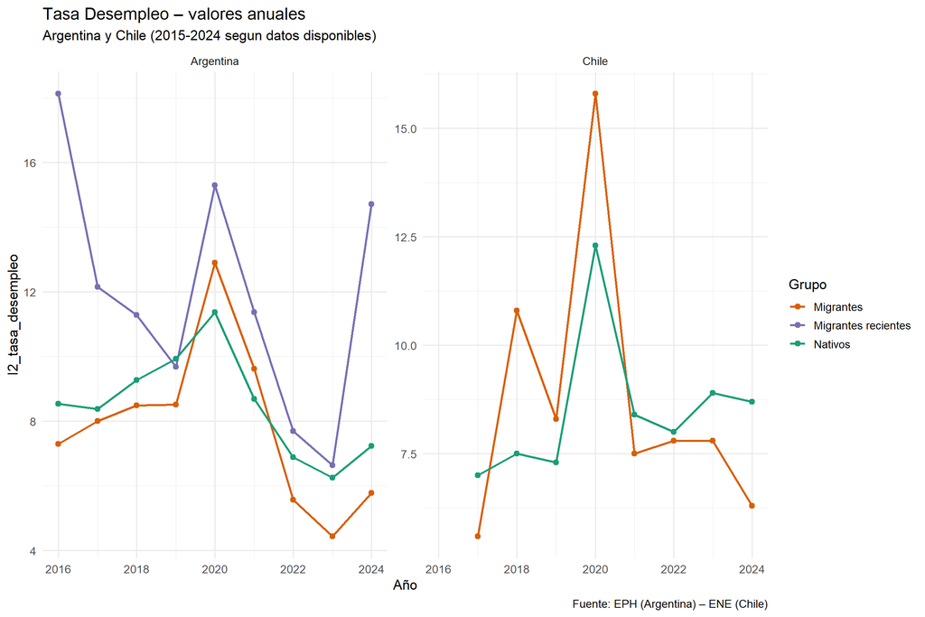

## Brechas nativos - migrantes

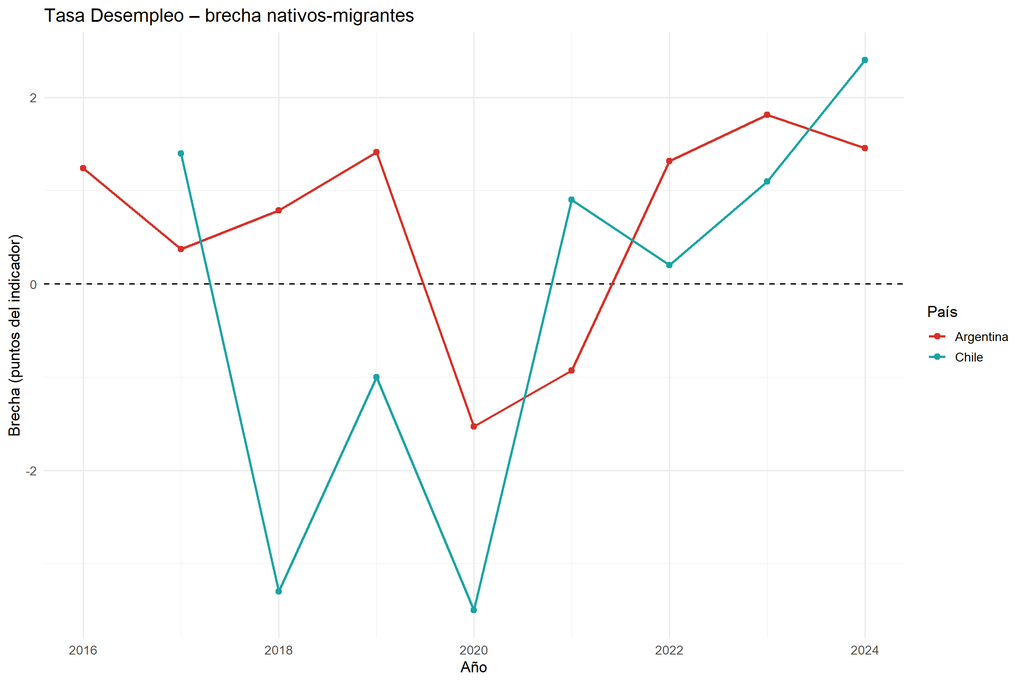

##Brechas - incorporación migración reciente

EN CHile la fuente ENE no contempla esta información.

Es más relevante el análisis para Argentina porque permite mayor comparibilidad con Chile donde la migración está más concentrada en migración reciente

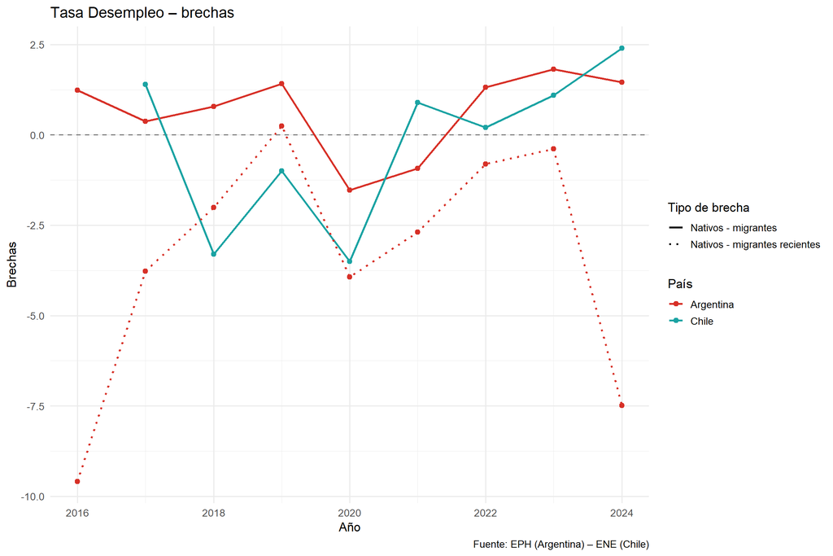

## Brechas estandarizadas

Bajo esta transformación, las brechas estandarizadas se interpretan como desviaciones respecto del promedio del indicador:

```
Z_(i,c,t)>0: integración relativa de la población migrante superior al promedio del indicador

Z_(i,c,t)<0: integración relativa inferior al promedio

Z_(i,c,t)=0: brecha equivalente al promedio del indicador
```

La magnitud de Z_(i,c,t)indica cuántos desvíos estándar se encuentra la brecha observada respecto de la media.

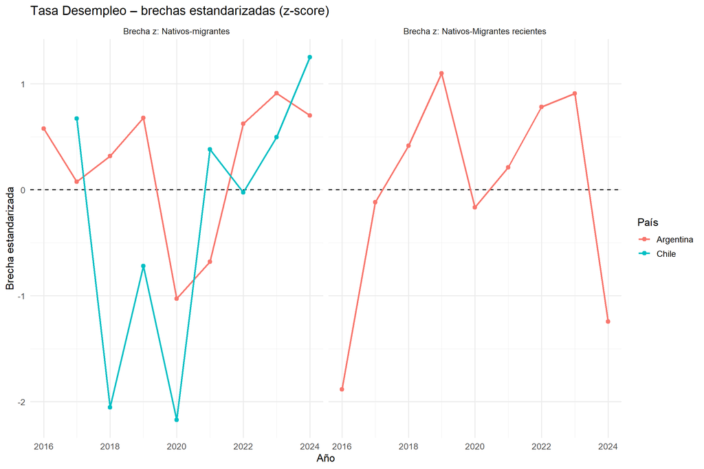

## Distribución de brechas

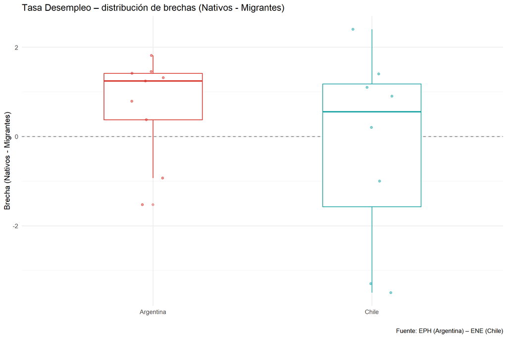

## Distribucion de brechas - grafico 2

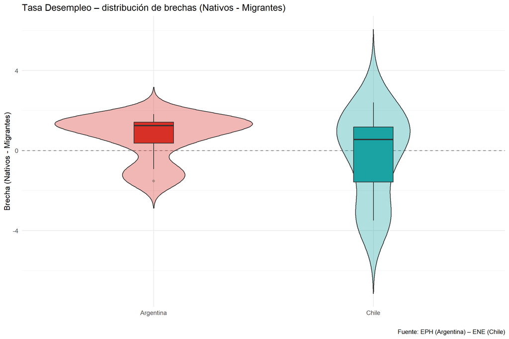

## distribucion de brechas migracion general y reciente en Argentina

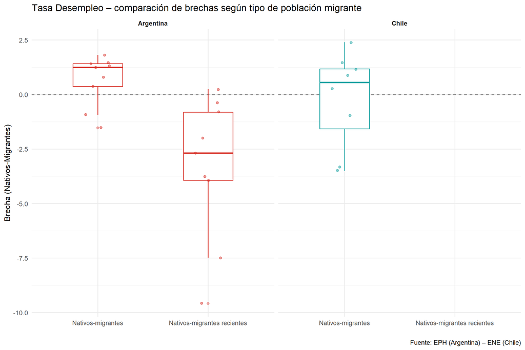

# (I3) Informalidad asalariada

## Datos completos

### Argentina

| pais | fuente | anio | indicador_clean | nativos | migrantes | migrantes_recientes | brecha_nat_mig | brecha_nat_rec |
| --- | --- | --- | --- | --- | --- | --- | --- | --- |
| Argentina | EPH | 2016 | Informalidad Asalariada | 32.85 | 47.60 | 55.06 | -14.75 | -22.22 |
| Argentina | EPH | 2017 | Informalidad Asalariada | 33.14 | 48.48 | 53.72 | -15.35 | -20.59 |
| Argentina | EPH | 2018 | Informalidad Asalariada | 33.46 | 49.60 | 54.86 | -16.14 | -21.39 |
| Argentina | EPH | 2019 | Informalidad Asalariada | 34.30 | 47.53 | 50.18 | -13.23 | -15.88 |
| Argentina | EPH | 2020 | Informalidad Asalariada | 29.64 | 46.76 | 59.99 | -17.12 | -30.35 |
| Argentina | EPH | 2021 | Informalidad Asalariada | 32.18 | 41.31 | 37.20 | -9.13 | -5.02 |
| Argentina | EPH | 2022 | Informalidad Asalariada | 36.04 | 47.02 | 35.29 | -10.98 | 0.75 |
| Argentina | EPH | 2023 | Informalidad Asalariada | 35.49 | 48.94 | 44.02 | -13.44 | -8.53 |
| Argentina | EPH | 2024 | Informalidad Asalariada | 35.68 | 45.29 | 46.48 | -9.61 | -10.80 |

### Chile

| pais | fuente | anio | indicador_clean | nativos | migrantes | migrantes_recientes | brecha_nat_mig | brecha_nat_rec |
| --- | --- | --- | --- | --- | --- | --- | --- | --- |
| Chile | ENE | 2017 | Informalidad Asalariada | 28.5 | 24.9 | NA | 3.6 | NA |
| Chile | ENE | 2018 | Informalidad Asalariada | 27.7 | 24.6 | NA | 3.1 | NA |
| Chile | ENE | 2019 | Informalidad Asalariada | 28.1 | 25.3 | NA | 2.8 | NA |
| Chile | ENE | 2020 | Informalidad Asalariada | 23.5 | 21.4 | NA | 2.1 | NA |
| Chile | ENE | 2021 | Informalidad Asalariada | 27.6 | 29.0 | NA | -1.4 | NA |
| Chile | ENE | 2022 | Informalidad Asalariada | 27.1 | 29.7 | NA | -2.6 | NA |
| Chile | ENE | 2023 | Informalidad Asalariada | 26.7 | 30.9 | NA | -4.2 | NA |
| Chile | ENE | 2024 | Informalidad Asalariada | 27.0 | 31.6 | NA | -4.6 | NA |

## Datos por perìodo

Brecha = Nativos - Migrantes (puntos porcentuales). Chile: ENE prioritaria; CASEN si corresponde al indicador.

| Período | Argentina Nativos | Argentina Migrantes | Argentina Brecha | Chile Nativos | Chile Migrantes | Chile Brecha |
| --- | --- | --- | --- | --- | --- | --- |
| 2015-2016 | 32.9 | 47.6 | −14.8 | NA | NA | NA |
| 2017-2019 | 33.6 | 48.5 | −14.9 | 28.1 | 24.9 | 3.2 |
| 2020-2022 | 32.6 | 45.0 | −12.4 | 26.1 | 26.7 | −0.6 |
| 2023-2024 | 35.6 | 47.1 | −11.5 | 26.9 | 31.2 | −4.4 |

## Serie temporal

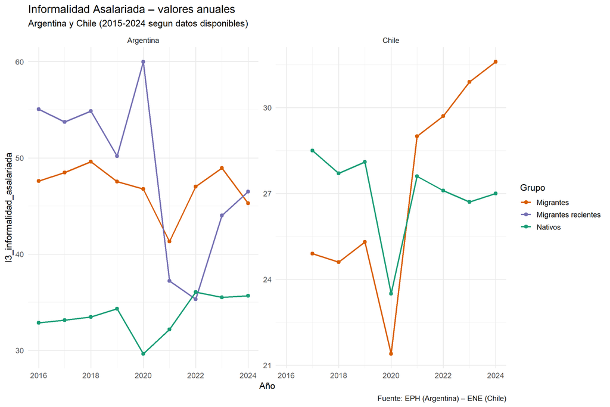

## Brechas nativos - migrantes

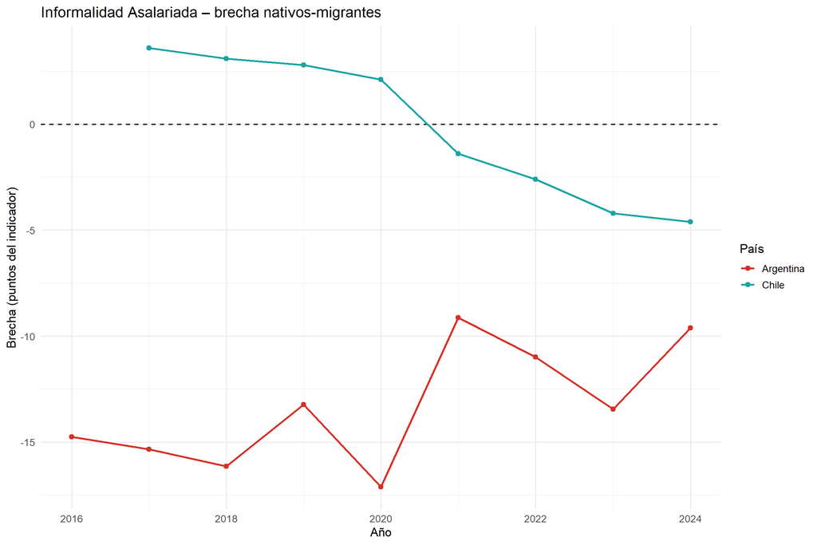

##Brechas - incorporación migración reciente

EN CHile la fuente ENE no contempla esta información.

Es más relevante el análisis para Argentina porque permite mayor comparibilidad con Chile donde la migración está más concentrada en migración reciente

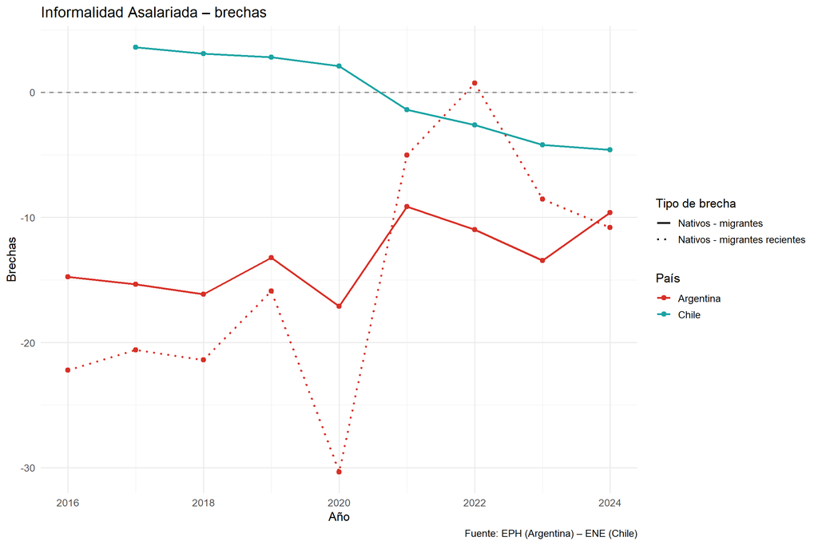

## Brechas estandarizadas

Bajo esta transformación, las brechas estandarizadas se interpretan como desviaciones respecto del promedio del indicador:

```
Z_(i,c,t)>0: integración relativa de la población migrante superior al promedio del indicador

Z_(i,c,t)<0: integración relativa inferior al promedio

Z_(i,c,t)=0: brecha equivalente al promedio del indicador
```

La magnitud de Z_(i,c,t)indica cuántos desvíos estándar se encuentra la brecha observada respecto de la media.

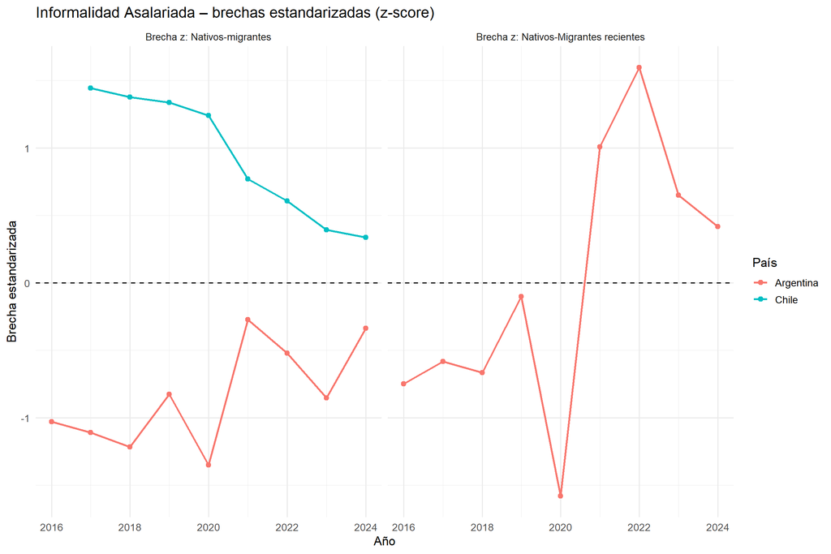

## Distribución de brechas

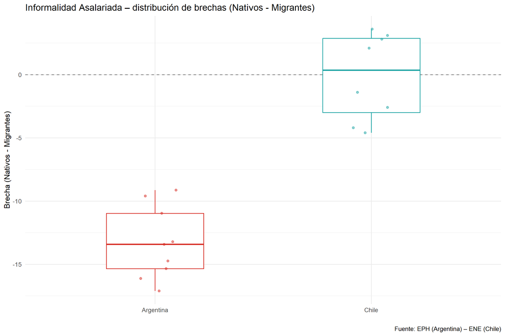

## Distribucion de brechas - grafico 2

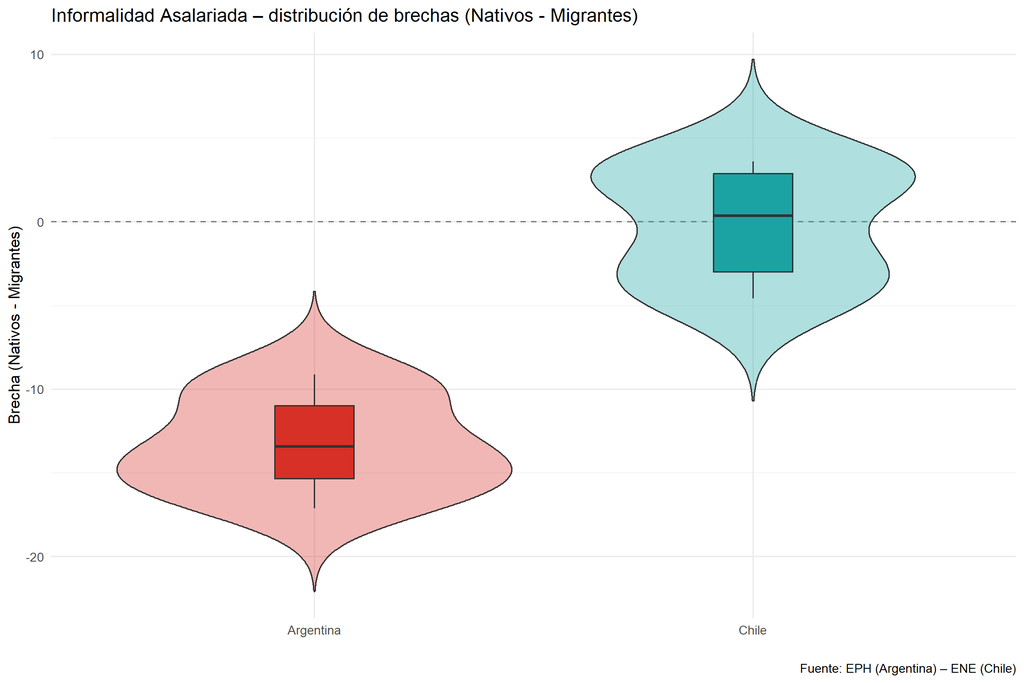

## distribucion de brechas migracion general y reciente en Argentina

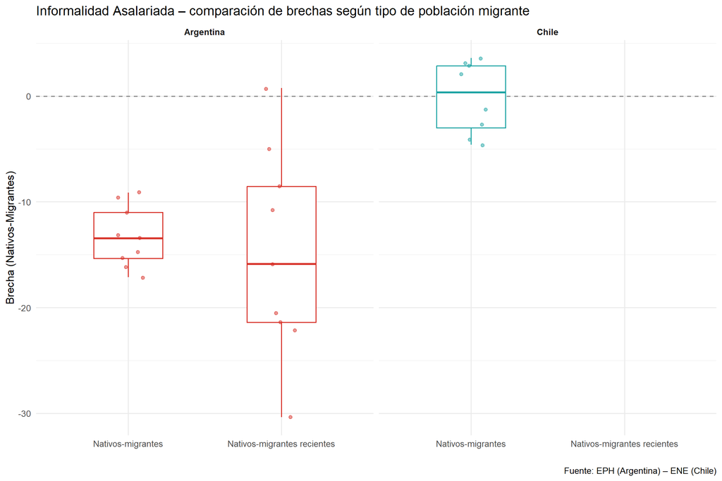

# (I4) Informalidad total

## Datos completos

### Argentina

| pais | fuente | anio | indicador_clean | nativos | migrantes | migrantes_recientes | brecha_nat_mig | brecha_nat_rec |
| --- | --- | --- | --- | --- | --- | --- | --- | --- |
| Argentina | EPH | 2016 | Informalidad Total | 46.26 | 60.96 | 62.96 | -14.71 | -16.70 |
| Argentina | EPH | 2017 | Informalidad Total | 46.75 | 61.21 | 64.32 | -14.46 | -17.57 |
| Argentina | EPH | 2018 | Informalidad Total | 47.31 | 61.28 | 60.68 | -13.97 | -13.37 |
| Argentina | EPH | 2019 | Informalidad Total | 48.76 | 61.09 | 56.74 | -12.34 | -7.98 |
| Argentina | EPH | 2020 | Informalidad Total | 47.08 | 62.91 | 66.01 | -15.84 | -18.94 |
| Argentina | EPH | 2021 | Informalidad Total | 48.18 | 55.31 | 44.67 | -7.13 | 3.51 |
| Argentina | EPH | 2022 | Informalidad Total | 50.10 | 60.66 | 47.24 | -10.55 | 2.86 |
| Argentina | EPH | 2023 | Informalidad Total | 49.09 | 61.92 | 53.48 | -12.84 | -4.39 |
| Argentina | EPH | 2024 | Informalidad Total | 49.96 | 59.94 | 57.27 | -9.97 | -7.31 |

### Chile

| pais | fuente | anio | indicador_clean | nativos | migrantes | migrantes_recientes | brecha_nat_mig | brecha_nat_rec |
| --- | --- | --- | --- | --- | --- | --- | --- | --- |
| Chile | CASEN | 2015 | Informalidad Total | 30.63 | 22.17 | 22.18 | 8.46 | 8.45 |
| Chile | CASEN | 2017 | Informalidad Total | 32.01 | 19.41 | 19.27 | 12.59 | 12.74 |
| Chile | CASEN | 2022 | Informalidad Total | 30.04 | 26.63 | 26.65 | 3.41 | 3.39 |
| Chile | CASEN | 2024 | Informalidad Total | 27.24 | 25.81 | 38.90 | 1.43 | -11.65 |

## Datos por perìodo

Brecha = Nativos - Migrantes (puntos porcentuales). Chile: ENE prioritaria; CASEN si corresponde al indicador.

| Período | Argentina Nativos | Argentina Migrantes | Argentina Brecha | Chile Nativos | Chile Migrantes | Chile Brecha |
| --- | --- | --- | --- | --- | --- | --- |
| 2015-2016 | 46.3 | 61.0 | −14.7 | 30.6 | 22.2 | 8.5 |
| 2017-2019 | 47.6 | 61.2 | −13.6 | 32.0 | 19.4 | 12.6 |
| 2020-2022 | 48.5 | 59.6 | −11.2 | 30.0 | 26.6 | 3.4 |
| 2023-2024 | 49.5 | 60.9 | −11.4 | 27.2 | 25.8 | 1.4 |

## Serie temporal

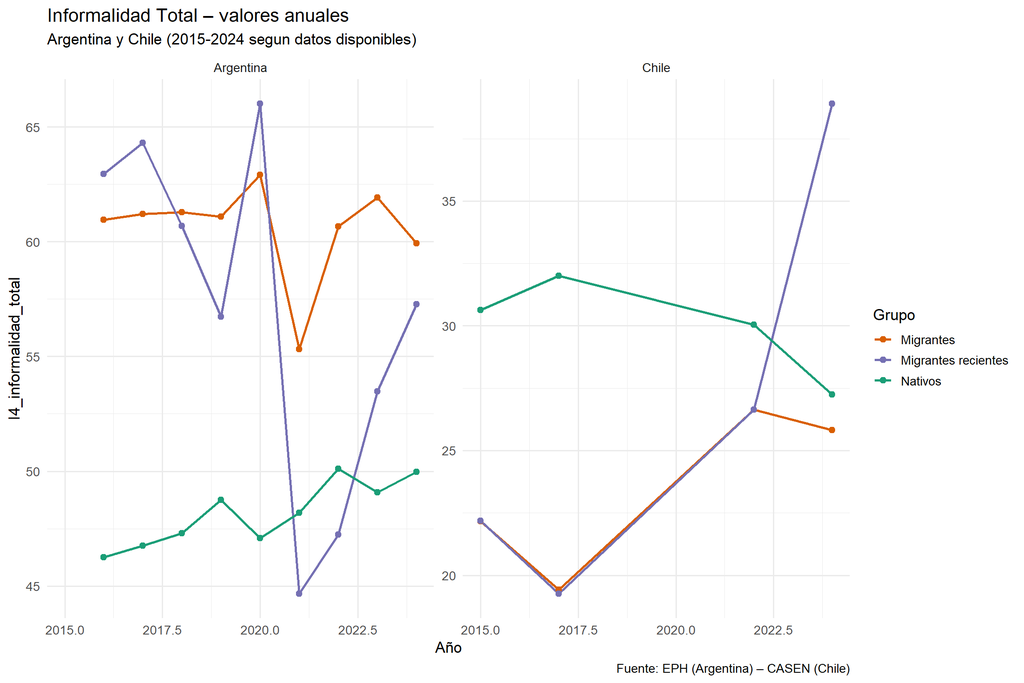

## Brechas nativos - migrantes

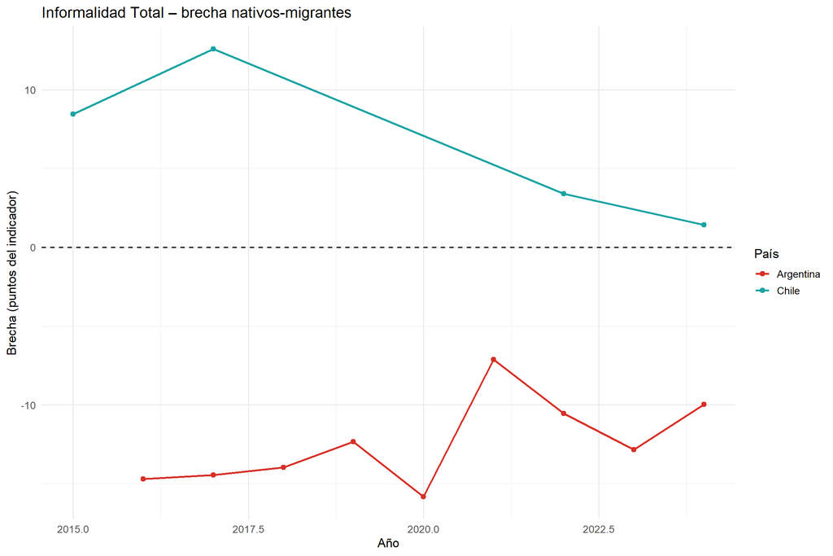

##Brechas - incorporación migración reciente

Es más relevante el análisis para Argentina porque permite mayor comparibilidad con Chile donde la migración está más concentrada en migración reciente

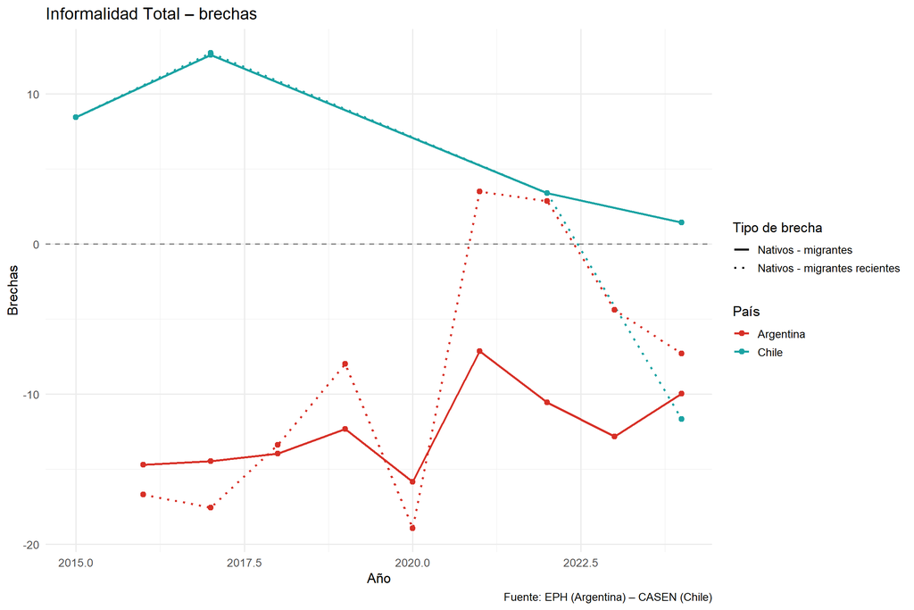

## Brechas estandarizadas

Bajo esta transformación, las brechas estandarizadas se interpretan como desviaciones respecto del promedio del indicador:

```
Z_(i,c,t)>0: integración relativa de la población migrante superior al promedio del indicador

Z_(i,c,t)<0: integración relativa inferior al promedio

Z_(i,c,t)=0: brecha equivalente al promedio del indicador
```

La magnitud de Z_(i,c,t)indica cuántos desvíos estándar se encuentra la brecha observada respecto de la media.

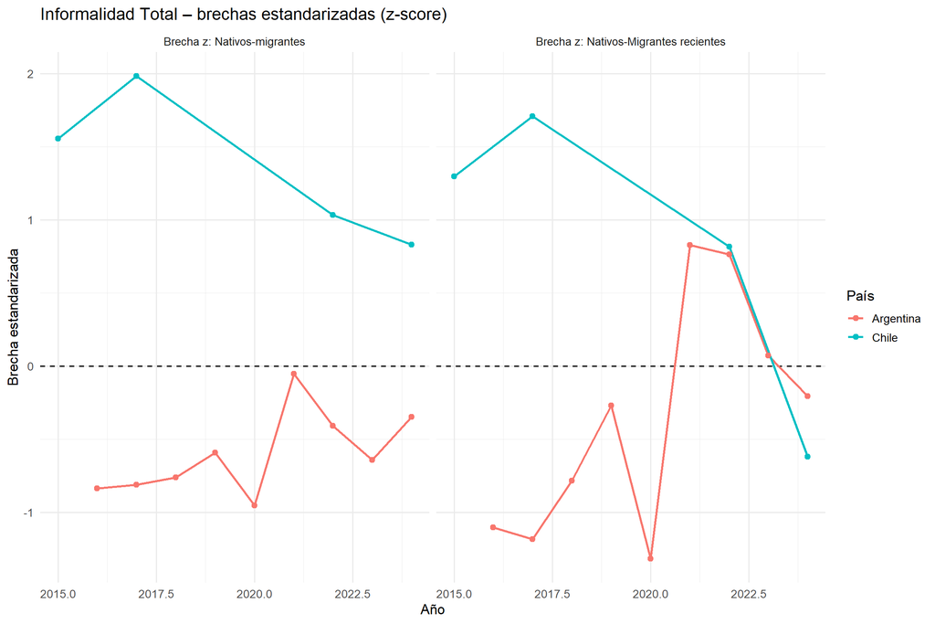

## Distribución de brechas

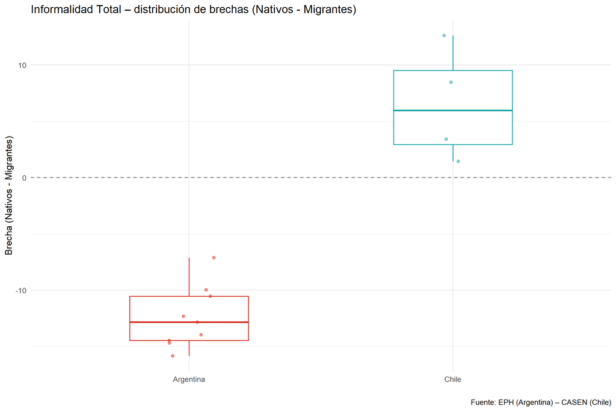

## Distribucion de brechas - grafico 2

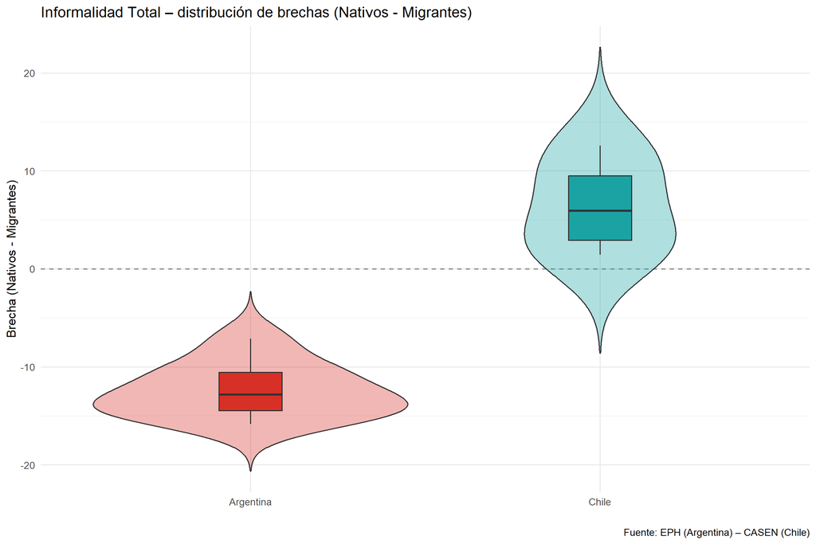

## distribucion de brechas migracion general y reciente en Argentina

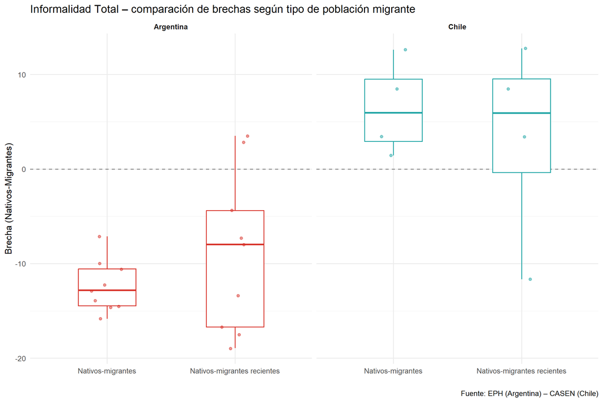

# (I5) Cuentapropismo

## Datos completos

### Argentina

| pais | fuente | anio | indicador_clean | nativos | migrantes | migrantes_recientes | brecha_nat_mig | brecha_nat_rec |
| --- | --- | --- | --- | --- | --- | --- | --- | --- |
| Argentina | EPH | 2016 | Cuentapropismo | 21.15 | 28.39 | 18.49 | -7.24 | 2.66 |
| Argentina | EPH | 2017 | Cuentapropismo | 21.62 | 28.14 | 24.05 | -6.52 | -2.43 |
| Argentina | EPH | 2018 | Cuentapropismo | 22.21 | 26.51 | 15.98 | -4.30 | 6.22 |
| Argentina | EPH | 2019 | Cuentapropismo | 23.39 | 28.54 | 15.11 | -5.14 | 8.28 |
| Argentina | EPH | 2020 | Cuentapropismo | 25.39 | 31.97 | 16.07 | -6.57 | 9.33 |
| Argentina | EPH | 2021 | Cuentapropismo | 24.66 | 27.68 | 12.23 | -3.03 | 12.42 |
| Argentina | EPH | 2022 | Cuentapropismo | 23.38 | 29.57 | 18.52 | -6.19 | 4.86 |
| Argentina | EPH | 2023 | Cuentapropismo | 22.53 | 29.01 | 18.19 | -6.48 | 4.34 |
| Argentina | EPH | 2024 | Cuentapropismo | 23.67 | 29.42 | 22.26 | -5.75 | 1.41 |

### Chile

| pais | fuente | anio | indicador_clean | nativos | migrantes | migrantes_recientes | brecha_nat_mig | brecha_nat_rec |
| --- | --- | --- | --- | --- | --- | --- | --- | --- |
| Chile | CASEN | 2015 | Cuentapropismo | 22.67 | 17.73 | 17.79 | 4.95 | 4.88 |
| Chile | CASEN | 2017 | Cuentapropismo | 25.35 | 15.62 | 15.46 | 9.73 | 9.89 |
| Chile | CASEN | 2022 | Cuentapropismo | 23.92 | 23.10 | 23.10 | 0.82 | 0.83 |
| Chile | CASEN | 2024 | Cuentapropismo | 20.73 | 20.89 | 30.73 | -0.16 | -10.00 |

## Datos por perìodo

Brecha = Nativos - Migrantes (puntos porcentuales). Chile: ENE prioritaria; CASEN si corresponde al indicador.

| Período | Argentina Nativos | Argentina Migrantes | Argentina Brecha | Chile Nativos | Chile Migrantes | Chile Brecha |
| --- | --- | --- | --- | --- | --- | --- |
| 2015-2016 | 21.1 | 28.4 | −7.2 | 22.7 | 17.7 | 4.9 |
| 2017-2019 | 22.4 | 27.7 | −5.3 | 25.4 | 15.6 | 9.7 |
| 2020-2022 | 24.5 | 29.7 | −5.3 | 23.9 | 23.1 | 0.8 |
| 2023-2024 | 23.1 | 29.2 | −6.1 | 20.7 | 20.9 | −0.2 |

## Serie temporal

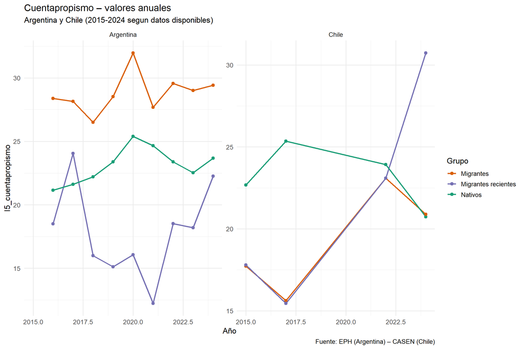

## Brechas nativos - migrantes

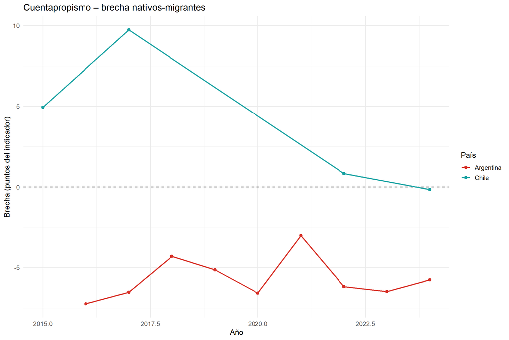

##Brechas - incorporación migración reciente

Es más relevante el análisis para Argentina porque permite mayor comparibilidad con Chile donde la migración está más concentrada en migración reciente

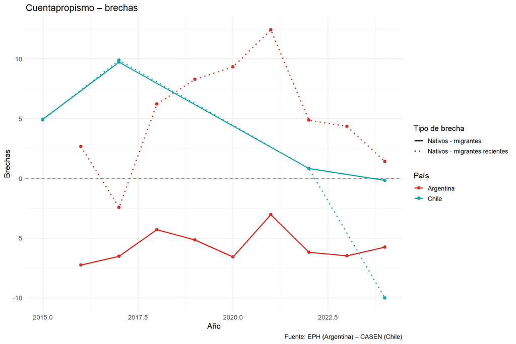